# 2. Kiểm định giả thuyết

Kiểm định các giả thuyết nghiên cứu trên tập dữ liệu **Wine Quality Red**.

**Mức ý nghĩa:** α = 0,05 cho tất cả kiểm định.

### Các giả thuyết nghiên cứu (H)

[output not shown]

### Các giả thuyết đối (H')

[output not shown]

## 2.1. Phương pháp kiểm định

[output not shown]

```python
import importlib
import pandas as pd
import numpy as np
import matplotlib.pyplot as plt
import seaborn as sns
from pathlib import Path

import hypothesis_testing
importlib.reload(hypothesis_testing)
from hypothesis_testing import hypothesis_test

sns.set_theme(style="whitegrid")
plt.rcParams["figure.figsize"] = (10, 6)
plt.rcParams["font.size"] = 11

ALPHA = 0.05
DATA_PATH = Path("dataset/winequality-red.csv")
df = pd.read_csv(DATA_PATH)
```

## 2.2. Kiểm định H0 / H'0 — Kruskal-Wallis

**Giả thuyết nghiên cứu (H0):** Nồng độ cồn trung bình không thay đổi đáng kể theo điểm chất lượng chủ quan.

**Giả thuyết đối (H'0):** Nồng độ cồn trung bình **có** thay đổi đáng kể theo điểm chất lượng.

**Phương pháp:** Kruskal-Wallis (phi tham số, so sánh nhiều nhóm độc lập dựa trên thứ hạng).

Trong đó: **H** là thống kê Kruskal-Wallis; **k** là số nhóm (số mức `quality`); bậc tự do **k − 1**.

$$H > \chi^2_{\alpha;\, k-1}$$

**Mức ý nghĩa:** α = 0,05.

| quality | Số mẫu | Trung bình | Trung vị | Độ lệch chuẩn |
| --- | --- | --- | --- | --- |
| 3 | 10 | 9.955000 | 9.925 | 0.818009 |
| 4 | 53 | 10.265094 | 10.000 | 0.934776 |
| 5 | 681 | 9.899706 | 9.700 | 0.736521 |
| 6 | 638 | 10.629519 | 10.500 | 1.049639 |
| 7 | 199 | 11.465913 | 11.500 | 0.961933 |
| 8 | 18 | 12.094444 | 12.150 | 1.224011 |

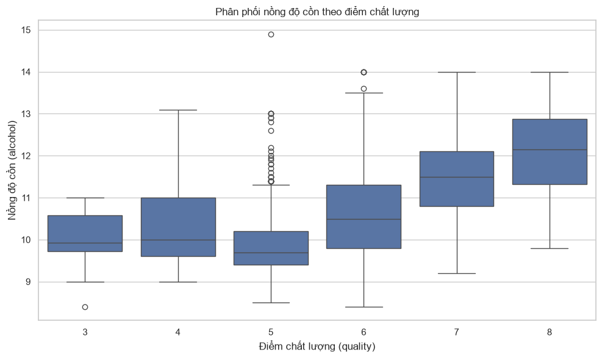

```python
# Thống kê mô tả alcohol theo từng mức quality
alcohol_by_quality = (
    df.groupby("quality")["alcohol"]
    .agg(["count", "mean", "median", "std"])
    .rename(columns={
        "count": "Số mẫu",
        "mean": "Trung bình",
        "median": "Trung vị",
        "std": "Độ lệch chuẩn",
    })
)
display(alcohol_by_quality)

fig, ax = plt.subplots()
sns.boxplot(data=df, x="quality", y="alcohol", ax=ax)
ax.set_xlabel("Điểm chất lượng (quality)")
ax.set_ylabel("Nồng độ cồn (alcohol)")
ax.set_title("Phân phối nồng độ cồn theo điểm chất lượng")
plt.tight_layout()
plt.show()
```

```python
# Kruskal-Wallis: so sánh alcohol giữa các nhóm quality
quality_levels = sorted(df["quality"].unique())
groups = [df.loc[df["quality"] == q, "alcohol"].values for q in quality_levels]

result_h0 = hypothesis_test(
    "kruskal_wallis", alternative="greater", groups=groups, alpha=ALPHA
)

H0 = "Nồng độ cồn trung bình không có thay đổi đáng kể theo điểm chất lượng chủ quan."
H0_prime = "Nồng độ cồn trung bình có thay đổi đáng kể theo điểm chất lượng."

print("=== Kiểm định Kruskal-Wallis: H0 / H'0 ===")
print(f"Số nhóm k = {result_h0['k']} (quality: {quality_levels})")
print(f"Bậc tự do k - 1 = {result_h0['df']}")
print(f"Thống kê {result_h0['statistic_name']} = {result_h0['statistic']:.4f}")
print(
    f"Giá trị tới hạn χ²_{{α; k-1}} = χ²_{{{ALPHA}; {result_h0['df']}}} "
    f"= {result_h0['critical_value']:.4f}"
)
print(f"p-value = {result_h0['p_value']:.6f}")
print(f"Mức ý nghĩa α = {ALPHA}")

reject = result_h0["p_value"] < ALPHA
print(
    f"\nH > χ²_{{α; k-1}} ?  {result_h0['statistic']:.4f} > "
    f"{result_h0['critical_value']:.4f} → {result_h0['statistic'] > result_h0['critical_value']}"
)

if reject:
    print("\nKết luận: Bác bỏ H0, chấp nhận H'0.")
    print(f"→ {H0_prime}")
else:
    print("\nKết luận: Không bác bỏ H0.")
    print(f"→ {H0}")
```

```
=== Kiểm định Kruskal-Wallis: H0 / H'0 ===
Số nhóm k = 6 (quality: [np.int64(3), np.int64(4), np.int64(5), np.int64(6), np.int64(7), np.int64(8)])
Bậc tự do k - 1 = 5
Thống kê H = 412.3768
Giá trị tới hạn χ²_{α; k-1} = χ²_{0.05; 5} = 11.0705
p-value = 0.000000
Mức ý nghĩa α = 0.05

H > χ²_{α; k-1} ?  412.3768 > 11.0705 → True

Kết luận: Bác bỏ H0, chấp nhận H'0.
→ Nồng độ cồn trung bình có thay đổi đáng kể theo điểm chất lượng.
```

## 2.3. Kiểm định H1 / H'1 — Welch t-test hai mẫu độc lập (một phía)

**Giả thuyết không (H1):** Hàm lượng cồn **không** có mối liên hệ tích cực đáng kể với chất lượng.

→ $\mu_{\text{cồn}}(\text{nhóm cao}) - \mu_{\text{cồn}}(\text{nhóm thấp}) \leq 0$

**Giả thuyết thay thế (H'1):** Rượu có hàm lượng cồn cao hơn có xu hướng được đánh giá chất lượng tốt hơn.

→ $\mu_{\text{cồn}}(\text{nhóm cao}) - \mu_{\text{cồn}}(\text{nhóm thấp}) > 0$

**Phương pháp:** Welch t-test hai mẫu độc lập (một phía, **không giả định phương sai bằng nhau**); dự phòng Wilcoxon rank-sum.

**Gom nhóm:**

| Nhóm | Tiêu chí | Mức quality gốc |
| --- | --- | --- |
| Quality cao | `quality` ≥ 6 | 6, 7, 8 |
| Quality thấp | `quality` ≤ 5 | 3, 4, 5 |

**Bác bỏ H1 khi:** p-value < α → chấp nhận H'1.

**Mức ý nghĩa:** α = 0,05.

```
=== Gom nhóm theo quality ===
```

| quality | Số mẫu | Nhóm gom |
| --- | --- | --- |
| 3 | 10 | Quality thấp (≤5) |
| 4 | 53 | Quality thấp (≤5) |
| 5 | 681 | Quality thấp (≤5) |
| 6 | 638 | Quality cao (≥6) |
| 7 | 199 | Quality cao (≥6) |
| 8 | 18 | Quality cao (≥6) |

```
=== Thống kê mô tả nồng độ cồn theo nhóm gom ===
```

| nhóm quality | Số mẫu | Trung bình | Trung vị | Độ lệch chuẩn | Phương sai |
| --- | --- | --- | --- | --- | --- |
| Quality cao (≥6) | 855 | 10.855029 | 10.8 | 1.106109 | 1.223478 |
| Quality thấp (≤5) | 744 | 9.926478 | 9.7 | 0.758007 | 0.574574 |

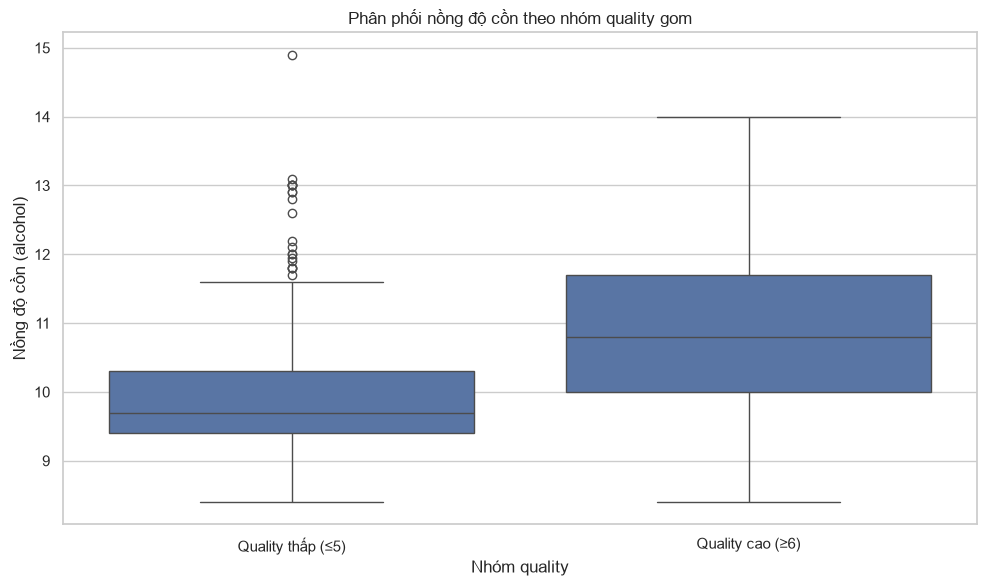

```
=== Phương sai hai nhóm (Welch không giả định σ₁ = σ₂) ===
Quality cao (≥6):  s² = 1.2235,  s = 1.1061
Quality thấp (≤5): s² = 0.5746,  s = 0.7580

=== Kiểm định Welch t hai mẫu độc lập: H1 / H'1 ===
Thống kê T = 19.7822
Bậc tự do Welch df = 1516.75
Giá trị tới hạn = 1.6459
p-value = 0.000000
Mức ý nghĩa α = 0.05

Bác bỏ H1 ? → True

=== Kiểm định Wilcoxon rank-sum ===
Phương pháp: mẫu lớn (n1=855, n2=744 > 10) → xấp xỉ Z
Thống kê U = 481313.0000
μ_U = 318060.0000,  σ_U = 9209.5603
Z = (U - μ_U) / σ_U = 17.7265
|Z| > Z_α ?  |17.7265| > 1.6449 → True
p-value = 0.000000
Bác bỏ H1 ? → True

Kết luận: Bác bỏ H1, chấp nhận H'1.
→ Rượu có hàm lượng cồn cao hơn có xu hướng được đánh giá chất lượng tốt hơn.
```

```python
# Gom nhóm quality cao / thấp
df_h1 = df.copy()
df_h1["nhóm quality"] = np.where(
    df_h1["quality"] >= 6, "Quality cao (≥6)", "Quality thấp (≤5)"
)

# Ánh xạ từng mức quality → nhóm gom
quality_to_group = (
    df.groupby("quality")
    .size()
    .rename("Số mẫu")
    .to_frame()
    .assign(
        **{
            "Nhóm gom": lambda x: x.index.map(
                lambda q: "Quality cao (≥6)" if q >= 6 else "Quality thấp (≤5)"
            )
        }
    )
)
print("=== Gom nhóm theo quality ===")
display(quality_to_group)

# Thống kê mô tả alcohol theo nhóm gom
alcohol_by_group = (
    df_h1.groupby("nhóm quality")["alcohol"]
    .agg(["count", "mean", "median", "std", "var"])
    .rename(
        columns={
            "count": "Số mẫu",
            "mean": "Trung bình",
            "median": "Trung vị",
            "std": "Độ lệch chuẩn",
            "var": "Phương sai",
        }
    )
)
print("\n=== Thống kê mô tả nồng độ cồn theo nhóm gom ===")
display(alcohol_by_group)

fig, ax = plt.subplots()
sns.boxplot(data=df_h1, x="nhóm quality", y="alcohol", order=["Quality thấp (≤5)", "Quality cao (≥6)"], ax=ax)
ax.set_xlabel("Nhóm quality")
ax.set_ylabel("Nồng độ cồn (alcohol)")
ax.set_title("Phân phối nồng độ cồn theo nhóm quality gom")
plt.tight_layout()
plt.show()

high_q = df_h1.loc[df_h1["quality"] >= 6, "alcohol"]
low_q = df_h1.loc[df_h1["quality"] <= 5, "alcohol"]

s1 = high_q.std(ddof=1)
s2 = low_q.std(ddof=1)
print("\n=== Phương sai hai nhóm (Welch không giả định σ₁ = σ₂) ===")
print(f"Quality cao (≥6):  s² = {s1**2:.4f},  s = {s1:.4f}")
print(f"Quality thấp (≤5): s² = {s2**2:.4f},  s = {s2:.4f}")

H1 = "Hàm lượng cồn không có mối liên hệ tích cực đáng kể với chất lượng."
H1_prime = "Rượu có hàm lượng cồn cao hơn có xu hướng được đánh giá chất lượng tốt hơn."

# Welch t-test hai mẫu độc lập (một phía: μ_cao > μ_thấp, bác bỏ H1 nếu p < α)
result_h1_t = hypothesis_test(
    "t_two_means_welch",
    x1=high_q.mean(),
    x2=low_q.mean(),
    s1=s1,
    s2=s2,
    n1=len(high_q),
    n2=len(low_q),
    alpha=ALPHA,
    alternative="greater",
)

print("\n=== Kiểm định Welch t hai mẫu độc lập: H1 / H'1 ===")
print(f"Thống kê {result_h1_t['statistic_name']} = {result_h1_t['statistic']:.4f}")
print(f"Bậc tự do Welch df = {result_h1_t['df']:.2f}")
print(f"Giá trị tới hạn = {result_h1_t['critical_value']:.4f}")
print(f"p-value = {result_h1_t['p_value']:.6f}")
print(f"Mức ý nghĩa α = {ALPHA}")

reject = result_h1_t["p_value"] < ALPHA
print(f"\nBác bỏ H1 ? → {reject}")

# Dự phòng phi tham số: Wilcoxon rank-sum
result_h1_w = hypothesis_test(
    "wilcoxon_rank_sum",
    sample1=high_q.values,
    sample2=low_q.values,
    alpha=ALPHA,
    alternative="greater",
)

print("\n=== Kiểm định Wilcoxon rank-sum ===")
w = result_h1_w
if w["use_z_approx"]:
    print(f"Phương pháp: mẫu lớn (n1={w['n1']}, n2={w['n2']} > 10) → xấp xỉ Z")
else:
    print(f"Phương pháp: mẫu nhỏ (n1={w['n1']}, n2={w['n2']} ≤ 10) → tra bảng U / p-value chính xác")
print(f"Thống kê U = {w['statistic']:.4f}")
if w["use_z_approx"]:
    print(f"μ_U = {w['mu_u']:.4f},  σ_U = {w['sigma_u']:.4f}")
    print(f"Z = (U - μ_U) / σ_U = {w['z']:.4f}")
    print(f"|Z| > Z_α ?  |{w['z']:.4f}| > {w['critical_value']:.4f} → {abs(w['z']) > w['critical_value']}")
print(f"p-value = {w['p_value']:.6f}")
print(f"Bác bỏ H1 ? → {w['reject_h0']}")

if reject:
    print("\nKết luận: Bác bỏ H1, chấp nhận H'1.")
    print(f"→ {H1_prime}")
else:
    print("\nKết luận: Không bác bỏ H1.")
    print(f"→ {H1}")
```

## 2.4. Kiểm định H2 / H'2 — Welch t-test hai mẫu độc lập (một phía)

**Giả thuyết không (H2):** Độ axit bay hơi cao **không** ảnh hưởng tiêu cực đến chất lượng của rượu vang đỏ.

→ $\mu_{\text{axit}}(\text{nhóm cao}) - \mu_{\text{axit}}(\text{nhóm thấp}) \geq 0$

**Giả thuyết thay thế (H'2):** Độ axit bay hơi **có** ảnh hưởng đáng kể đến chất lượng của rượu vang đỏ.

→ $\mu_{\text{axit}}(\text{nhóm cao}) - \mu_{\text{axit}}(\text{nhóm thấp}) < 0$

**Phương pháp:** Welch t-test hai mẫu độc lập (một phía, **không giả định phương sai bằng nhau**); dự phòng Wilcoxon rank-sum.

**Gom nhóm:**

| Nhóm | Tiêu chí | Mức quality gốc |
| --- | --- | --- |
| Quality cao | `quality` ≥ 6 | 6, 7, 8 |
| Quality thấp | `quality` ≤ 5 | 3, 4, 5 |

**Bác bỏ H2 khi:** p-value < α → chấp nhận H'2.

**Mức ý nghĩa:** α = 0,05.

```
=== Thống kê mô tả độ axit bay hơi theo nhóm gom ===
```

| nhóm quality | Số mẫu | Trung bình | Trung vị | Độ lệch chuẩn | Phương sai |
| --- | --- | --- | --- | --- | --- |
| Quality cao (≥6) | 855 | 0.474146 | 0.46 | 0.161999 | 0.026244 |
| Quality thấp (≤5) | 744 | 0.589503 | 0.59 | 0.177956 | 0.031668 |

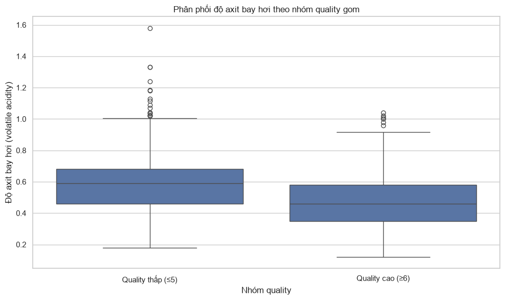

```
=== Phương sai hai nhóm (Welch không giả định σ₁ = σ₂) ===
Quality cao (≥6):  s² = 0.0262,  s = 0.1620
Quality thấp (≤5): s² = 0.0317,  s = 0.1780

=== Kiểm định Welch t hai mẫu độc lập: H2 / H'2 ===
Thống kê T = -13.4775
Bậc tự do Welch df = 1515.37
Giá trị tới hạn = -1.6459
p-value = 0.000000
Mức ý nghĩa α = 0.05

Bác bỏ H2 ? → True

=== Kiểm định Wilcoxon rank-sum ===
Phương pháp: mẫu lớn (n1=855, n2=744 > 10) → xấp xỉ Z
Thống kê U = 197208.0000
μ_U = 318060.0000,  σ_U = 9209.5603
Z = (U - μ_U) / σ_U = -13.1225
|Z| > Z_α ?  |-13.1225| > -1.6449 → True
p-value = 0.000000
Bác bỏ H2 ? → True

Kết luận: Bác bỏ H2, chấp nhận H'2.
→ Độ axit bay hơi có ảnh hưởng đáng kể đến chất lượng của rượu vang đỏ.
```

```python
# Gom nhóm quality cao / thấp — biến volatile acidity
df_h2 = df.copy()
df_h2["nhóm quality"] = np.where(
    df_h2["quality"] >= 6, "Quality cao (≥6)", "Quality thấp (≤5)"
)

# Thống kê mô tả axit bay hơi theo nhóm gom
va_by_group = (
    df_h2.groupby("nhóm quality")["volatile acidity"]
    .agg(["count", "mean", "median", "std", "var"])
    .rename(
        columns={
            "count": "Số mẫu",
            "mean": "Trung bình",
            "median": "Trung vị",
            "std": "Độ lệch chuẩn",
            "var": "Phương sai",
        }
    )
)
print("=== Thống kê mô tả độ axit bay hơi theo nhóm gom ===")
display(va_by_group)

fig, ax = plt.subplots()
sns.boxplot(
    data=df_h2,
    x="nhóm quality",
    y="volatile acidity",
    order=["Quality thấp (≤5)", "Quality cao (≥6)"],
    ax=ax,
)
ax.set_xlabel("Nhóm quality")
ax.set_ylabel("Độ axit bay hơi (volatile acidity)")
ax.set_title("Phân phối độ axit bay hơi theo nhóm quality gom")
plt.tight_layout()
plt.show()

high_va = df_h2.loc[df_h2["quality"] >= 6, "volatile acidity"]
low_va = df_h2.loc[df_h2["quality"] <= 5, "volatile acidity"]

s1 = high_va.std(ddof=1)
s2 = low_va.std(ddof=1)
print("\n=== Phương sai hai nhóm (Welch không giả định σ₁ = σ₂) ===")
print(f"Quality cao (≥6):  s² = {s1**2:.4f},  s = {s1:.4f}")
print(f"Quality thấp (≤5): s² = {s2**2:.4f},  s = {s2:.4f}")

H2 = "Độ axit bay hơi cao không ảnh hưởng tiêu cực đến chất lượng của rượu vang đỏ."
H2_prime = "Độ axit bay hơi có ảnh hưởng đáng kể đến chất lượng của rượu vang đỏ."

# Welch t-test hai mẫu độc lập (một phía: μ_cao < μ_thấp, bác bỏ H2 nếu p < α)
result_h2_t = hypothesis_test(
    "t_two_means_welch",
    x1=high_va.mean(),
    x2=low_va.mean(),
    s1=s1,
    s2=s2,
    n1=len(high_va),
    n2=len(low_va),
    alpha=ALPHA,
    alternative="less",
)

print("\n=== Kiểm định Welch t hai mẫu độc lập: H2 / H'2 ===")
print(f"Thống kê {result_h2_t['statistic_name']} = {result_h2_t['statistic']:.4f}")
print(f"Bậc tự do Welch df = {result_h2_t['df']:.2f}")
print(f"Giá trị tới hạn = {result_h2_t['critical_value']:.4f}")
print(f"p-value = {result_h2_t['p_value']:.6f}")
print(f"Mức ý nghĩa α = {ALPHA}")

reject = result_h2_t["p_value"] < ALPHA
print(f"\nBác bỏ H2 ? → {reject}")

# Dự phòng phi tham số: Wilcoxon rank-sum
result_h2_w = hypothesis_test(
    "wilcoxon_rank_sum",
    sample1=high_va.values,
    sample2=low_va.values,
    alpha=ALPHA,
    alternative="less",
)

print("\n=== Kiểm định Wilcoxon rank-sum ===")
w = result_h2_w
if w["use_z_approx"]:
    print(f"Phương pháp: mẫu lớn (n1={w['n1']}, n2={w['n2']} > 10) → xấp xỉ Z")
else:
    print(f"Phương pháp: mẫu nhỏ (n1={w['n1']}, n2={w['n2']} ≤ 10) → tra bảng U / p-value chính xác")
print(f"Thống kê U = {w['statistic']:.4f}")
if w["use_z_approx"]:
    print(f"μ_U = {w['mu_u']:.4f},  σ_U = {w['sigma_u']:.4f}")
    print(f"Z = (U - μ_U) / σ_U = {w['z']:.4f}")
    print(f"|Z| > Z_α ?  |{w['z']:.4f}| > {w['critical_value']:.4f} → {abs(w['z']) > w['critical_value']}")
print(f"p-value = {w['p_value']:.6f}")
print(f"Bác bỏ H2 ? → {w['reject_h0']}")

if reject:
    print("\nKết luận: Bác bỏ H2, chấp nhận H'2.")
    print(f"→ {H2_prime}")
else:
    print("\nKết luận: Không bác bỏ H2.")
    print(f"→ {H2}")
```

## 2.5. Kiểm định H3 / H'3 — Welch t-test hai mẫu độc lập (một phía)

**Giả thuyết không (H3):** Hàm lượng sunfat cao **không** góp phần duy trì và nâng cao chất lượng rượu vang đỏ.

→ $\mu_{\text{sulphates}}(\text{nhóm cao}) - \mu_{\text{sulphates}}(\text{nhóm thấp}) \leq 0$

**Giả thuyết thay thế (H'3):** Hàm lượng sunfat **có** góp phần nâng cao đáng kể đến chất lượng rượu vang đỏ.

→ $\mu_{\text{sulphates}}(\text{nhóm cao}) - \mu_{\text{sulphates}}(\text{nhóm thấp}) > 0$

**Phương pháp:** Welch t-test hai mẫu độc lập (một phía, **không giả định phương sai bằng nhau**); dự phòng Wilcoxon rank-sum.

**Gom nhóm:**

| Nhóm | Tiêu chí | Mức quality gốc |
| --- | --- | --- |
| Quality cao | `quality` ≥ 6 | 6, 7, 8 |
| Quality thấp | `quality` ≤ 5 | 3, 4, 5 |

**Mức ý nghĩa:** α = 0,05.

```
=== Gom nhóm theo quality ===
```

| quality | Số mẫu | Nhóm gom |
| --- | --- | --- |
| 3 | 10 | Quality thấp (≤5) |
| 4 | 53 | Quality thấp (≤5) |
| 5 | 681 | Quality thấp (≤5) |
| 6 | 638 | Quality cao (≥6) |
| 7 | 199 | Quality cao (≥6) |
| 8 | 18 | Quality cao (≥6) |

```
=== Thống kê mô tả nồng độ cồn theo nhóm gom ===
```

| nhóm quality | Số mẫu | Trung bình | Trung vị | Độ lệch chuẩn | Phương sai |
| --- | --- | --- | --- | --- | --- |
| Quality cao (≥6) | 855 | 0.692620 | 0.66 | 0.155558 | 0.024198 |
| Quality thấp (≤5) | 744 | 0.618535 | 0.58 | 0.176194 | 0.031044 |

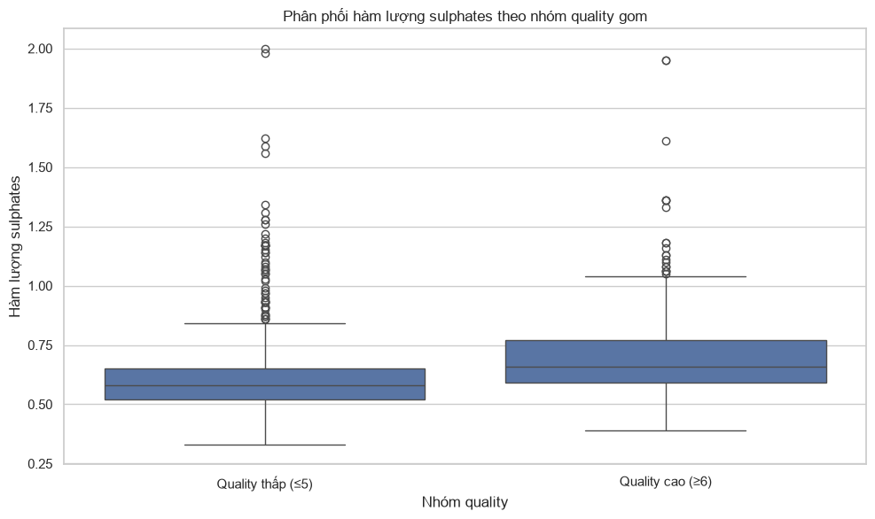

```
=== Phương sai hai nhóm (Welch không giả định σ₁ = σ₂) ===
Quality cao (≥6):  s² = 0.0242,  s = 0.1556
Quality thấp (≤5): s² = 0.0310,  s = 0.1762

=== Kiểm định Welch t hai mẫu độc lập: H3 / H'3 ===
Thống kê T = 8.8531
Bậc tự do Welch df = 1494.54
Giá trị tới hạn = 1.6459
p-value = 0.000000
Mức ý nghĩa α = 0.05

Bác bỏ H3 ? → True

=== Kiểm định Wilcoxon rank-sum ===
Phương pháp: mẫu lớn (n1=855, n2=744 > 10) → xấp xỉ Z
Thống kê U = 440968.0000
μ_U = 318060.0000,  σ_U = 9209.5603
Z = (U - μ_U) / σ_U = 13.3457
|Z| > Z_α ?  |13.3457| > 1.6449 → True
p-value = 0.000000
Bác bỏ H3 ? → True

Kết luận: Bác bỏ H3, chấp nhận H'3.
→ Hàm lượng sunfat có góp phần nâng cao đáng kể đến chất lượng rượu vang đỏ.
```

```python
# Gom nhóm quality cao / thấp
df_h3 = df.copy()
df_h3["nhóm quality"] = np.where(
    df_h3["quality"] >= 6, "Quality cao (≥6)", "Quality thấp (≤5)"
)

# Ánh xạ từng mức quality → nhóm gom
quality_to_group = (
    df.groupby("quality")
    .size()
    .rename("Số mẫu")
    .to_frame()
    .assign(
        **{
            "Nhóm gom": lambda x: x.index.map(
                lambda q: "Quality cao (≥6)" if q >= 6 else "Quality thấp (≤5)"
            )
        }
    )
)
print("=== Gom nhóm theo quality ===")
display(quality_to_group)

# Thống kê mô tả sulphates theo nhóm gom
sulphates_by_group = (
    df_h1.groupby("nhóm quality")["sulphates"]
    .agg(["count", "mean", "median", "std", "var"])
    .rename(
        columns={
            "count": "Số mẫu",
            "mean": "Trung bình",
            "median": "Trung vị",
            "std": "Độ lệch chuẩn",
            "var": "Phương sai",
        }
    )
)
print("\n=== Thống kê mô tả nồng độ cồn theo nhóm gom ===")
display(sulphates_by_group)

fig, ax = plt.subplots()
sns.boxplot(data=df_h3, x="nhóm quality", y="sulphates", order=["Quality thấp (≤5)", "Quality cao (≥6)"], ax=ax)
ax.set_xlabel("Nhóm quality")
ax.set_ylabel("Hàm lượng sulphates")
ax.set_title("Phân phối hàm lượng sulphates theo nhóm quality gom")
plt.tight_layout()
plt.show()

high_sulphates = df_h3.loc[df_h3["quality"] >= 6, "sulphates"]
low_sulphates = df_h3.loc[df_h3["quality"] <= 5, "sulphates"]

s1 = high_sulphates.std(ddof=1)
s2 = low_sulphates.std(ddof=1)
print("\n=== Phương sai hai nhóm (Welch không giả định σ₁ = σ₂) ===")
print(f"Quality cao (≥6):  s² = {s1**2:.4f},  s = {s1:.4f}")
print(f"Quality thấp (≤5): s² = {s2**2:.4f},  s = {s2:.4f}")

H3 = "Hàm lượng sunfat cao không góp phần duy trì và nâng cao chất lượng rượu vang đỏ."
H3_prime = "Hàm lượng sunfat có góp phần nâng cao đáng kể đến chất lượng rượu vang đỏ."

# Welch t-test hai mẫu độc lập (một phía: μ_cao > μ_thấp, bác bỏ H3 nếu p < α)
result_h3_t = hypothesis_test(
    "t_two_means_welch",
    x1=high_sulphates.mean(),
    x2=low_sulphates.mean(),
    s1=s1,
    s2=s2,
    n1=len(high_sulphates),
    n2=len(low_sulphates),
    alpha=ALPHA,
    alternative="greater",
)

print("\n=== Kiểm định Welch t hai mẫu độc lập: H3 / H'3 ===")
print(f"Thống kê {result_h3_t['statistic_name']} = {result_h3_t['statistic']:.4f}")
print(f"Bậc tự do Welch df = {result_h3_t['df']:.2f}")
print(f"Giá trị tới hạn = {result_h3_t['critical_value']:.4f}")
print(f"p-value = {result_h3_t['p_value']:.6f}")
print(f"Mức ý nghĩa α = {ALPHA}")

reject = result_h3_t["p_value"] < ALPHA
print(f"\nBác bỏ H3 ? → {reject}")

# Dự phòng phi tham số: Wilcoxon rank-sum
result_h3_w = hypothesis_test(
    "wilcoxon_rank_sum",
    sample1=high_sulphates.values,
    sample2=low_sulphates.values,
    alpha=ALPHA,
    alternative="greater",
)

print("\n=== Kiểm định Wilcoxon rank-sum ===")
w = result_h3_w
if w["use_z_approx"]:
    print(f"Phương pháp: mẫu lớn (n1={w['n1']}, n2={w['n2']} > 10) → xấp xỉ Z")
else:
    print(f"Phương pháp: mẫu nhỏ (n1={w['n1']}, n2={w['n2']} ≤ 10) → tra bảng U / p-value chính xác")
print(f"Thống kê U = {w['statistic']:.4f}")
if w["use_z_approx"]:
    print(f"μ_U = {w['mu_u']:.4f},  σ_U = {w['sigma_u']:.4f}")
    print(f"Z = (U - μ_U) / σ_U = {w['z']:.4f}")
    print(f"|Z| > Z_α ?  |{w['z']:.4f}| > {w['critical_value']:.4f} → {abs(w['z']) > w['critical_value']}")
print(f"p-value = {w['p_value']:.6f}")
print(f"Bác bỏ H3 ? → {w['reject_h0']}")

if reject:
    print("\nKết luận: Bác bỏ H3, chấp nhận H'3.")
    print(f"→ {H3_prime}")
else:
    print("\nKết luận: Không bác bỏ H3.")
    print(f"→ {H3}")
```

## 2.6. Kiểm định H4 / H'4 — Welch t-test hai mẫu độc lập (một phía)

**Giả thuyết không (H4):** Xác định xem hàm lượng axit citric **không** có ảnh hưởng giúp rượu vang đỏ đạt chất lượng tốt hơn.

→ $\mu_{\text{axit citric}}(\text{nhóm cao}) - \mu_{\text{axit citric}}(\text{nhóm thấp}) \leq 0$

**Giả thuyết thay thế (H'4):** Hàm lượng axit citric **có** ảnh hưởng đáng kể đến chất lượng rượu vang đỏ.

→ $\mu_{\text{axit citric}}(\text{nhóm cao}) - \mu_{\text{axit citric}}(\text{nhóm thấp}) > 0$

**Phương pháp:** Welch t-test hai mẫu độc lập (một phía, **không giả định phương sai bằng nhau**); dự phòng Wilcoxon rank-sum.

**Gom nhóm:**

| Nhóm | Tiêu chí | Mức quality gốc |
| --- | --- | --- |
| Quality cao | `quality` ≥ 6 | 6, 7, 8 |
| Quality thấp | `quality` ≤ 5 | 3, 4, 5 |

**Bác bỏ H4 khi:** p-value < α → chấp nhận H'4.

**Mức ý nghĩa:** α = 0,05.

```
=== Gom nhóm theo quality ===
```

| quality | Số mẫu | Nhóm gom |
| --- | --- | --- |
| 3 | 10 | Quality thấp (≤5) |
| 4 | 53 | Quality thấp (≤5) |
| 5 | 681 | Quality thấp (≤5) |
| 6 | 638 | Quality cao (≥6) |
| 7 | 199 | Quality cao (≥6) |
| 8 | 18 | Quality cao (≥6) |

```
=== Thống kê mô tả nồng độ cồn theo nhóm gom ===
```

| nhóm quality | Số mẫu | Trung bình | Trung vị | Độ lệch chuẩn | Phương sai |
| --- | --- | --- | --- | --- | --- |
| Quality cao (≥6) | 855 | 0.299883 | 0.31 | 0.199889 | 0.039955 |
| Quality thấp (≤5) | 744 | 0.237755 | 0.22 | 0.183368 | 0.033624 |

[figure not shown]

```
=== Phương sai hai nhóm (Welch không giả định σ₁ = σ₂) ===
Quality cao (≥6):  s² = 0.0400,  s = 0.1999
Quality thấp (≤5): s² = 0.0336,  s = 0.1834

=== Kiểm định Welch t hai mẫu độc lập: H4 / H'4 ===
Thống kê T = 6.4799
Bậc tự do Welch df = 1592.54
Giá trị tới hạn = 1.6458
p-value = 0.000000
Mức ý nghĩa α = 0.05

Bác bỏ H4 ? → True

=== Kiểm định Wilcoxon rank-sum ===
Phương pháp: mẫu lớn (n1=855, n2=744 > 10) → xấp xỉ Z
Thống kê U = 376272.5000
μ_U = 318060.0000,  σ_U = 9209.5603
Z = (U - μ_U) / σ_U = 6.3209
|Z| > Z_α ?  |6.3209| > 1.6449 → True
p-value = 0.000000
Bác bỏ H4 ? → True

Kết luận: Bác bỏ H4, chấp nhận H'4.
→ Hàm lượng axit citric có ảnh hưởng đáng kể đến chất lượng rượu vang đỏ.
```

```python
# Gom nhóm quality cao / thấp
df_h4 = df.copy()
df_h4["nhóm quality"] = np.where(
    df_h4["quality"] >= 6, "Quality cao (≥6)", "Quality thấp (≤5)"
)

# Ánh xạ từng mức quality → nhóm gom
quality_to_group = (
    df_h4.groupby("quality")
    .size()
    .rename("Số mẫu")
    .to_frame()
    .assign(
        **{
            "Nhóm gom": lambda x: x.index.map(
                lambda q: "Quality cao (≥6)" if q >= 6 else "Quality thấp (≤5)"
            )
        }
    )
)
print("=== Gom nhóm theo quality ===")
display(quality_to_group)

# Thống kê mô tả axit citric theo nhóm gom
citric_acid_by_group = (
    df_h4.groupby("nhóm quality")["citric acid"]
    .agg(["count", "mean", "median", "std", "var"])
    .rename(
        columns={
            "count": "Số mẫu",
            "mean": "Trung bình",
            "median": "Trung vị",
            "std": "Độ lệch chuẩn",
            "var": "Phương sai",
        }
    )
)
print("\n=== Thống kê mô tả nồng độ cồn theo nhóm gom ===")
display(citric_acid_by_group)

fig, ax = plt.subplots()
sns.boxplot(data=df_h4, x="nhóm quality", y="citric acid", order=["Quality thấp (≤5)", "Quality cao (≥6)"], ax=ax)
ax.set_xlabel("Nhóm quality")
ax.set_ylabel("Hàm lượng axit citric")
ax.set_title("Phân phối nồng độ cồn theo nhóm quality gom")
plt.tight_layout()
plt.show()

high_q = df_h4.loc[df_h4["quality"] >= 6, "citric acid"]
low_q = df_h4.loc[df_h4["quality"] <= 5, "citric acid"]

s1 = high_q.std(ddof=1)
s2 = low_q.std(ddof=1)
print("\n=== Phương sai hai nhóm (Welch không giả định σ₁ = σ₂) ===")
print(f"Quality cao (≥6):  s² = {s1**2:.4f},  s = {s1:.4f}")
print(f"Quality thấp (≤5): s² = {s2**2:.4f},  s = {s2:.4f}")

H4 = "Xác định xem hàm lượng axit citric không có ảnh hưởng giúp rượu vang đỏ đạt chất lượng tốt hơn."
H4_prime = "Hàm lượng axit citric có ảnh hưởng đáng kể đến chất lượng rượu vang đỏ."

# Welch t-test hai mẫu độc lập (một phía: μ_cao > μ_thấp (do H'4 kiểm định theo hướng tích cực), bác bỏ H4 nếu p < α)
result_h4_t = hypothesis_test(
    "t_two_means_welch",
    x1=high_q.mean(),
    x2=low_q.mean(),
    s1=s1,
    s2=s2,
    n1=len(high_q),
    n2=len(low_q),
    alpha=ALPHA,
    alternative="greater",
)

print("\n=== Kiểm định Welch t hai mẫu độc lập: H4 / H'4 ===")
print(f"Thống kê {result_h4_t['statistic_name']} = {result_h4_t['statistic']:.4f}")
print(f"Bậc tự do Welch df = {result_h4_t['df']:.2f}")
print(f"Giá trị tới hạn = {result_h4_t['critical_value']:.4f}")
print(f"p-value = {result_h4_t['p_value']:.6f}")
print(f"Mức ý nghĩa α = {ALPHA}")

reject = result_h4_t["p_value"] < ALPHA
print(f"\nBác bỏ H4 ? → {reject}")

# Dự phòng phi tham số: Wilcoxon rank-sum
result_h4_w = hypothesis_test(
    "wilcoxon_rank_sum",
    sample1=high_q.values,
    sample2=low_q.values,
    alpha=ALPHA,
    alternative="greater",
)

print("\n=== Kiểm định Wilcoxon rank-sum ===")
w = result_h4_w
if w["use_z_approx"]:
    print(f"Phương pháp: mẫu lớn (n1={w['n1']}, n2={w['n2']} > 10) → xấp xỉ Z")
else:
    print(f"Phương pháp: mẫu nhỏ (n1={w['n1']}, n2={w['n2']} ≤ 10) → tra bảng U / p-value chính xác")
print(f"Thống kê U = {w['statistic']:.4f}")
if w["use_z_approx"]:
    print(f"μ_U = {w['mu_u']:.4f},  σ_U = {w['sigma_u']:.4f}")
    print(f"Z = (U - μ_U) / σ_U = {w['z']:.4f}")
    print(f"|Z| > Z_α ?  |{w['z']:.4f}| > {w['critical_value']:.4f} → {abs(w['z']) > w['critical_value']}")
print(f"p-value = {w['p_value']:.6f}")
print(f"Bác bỏ H4 ? → {w['reject_h0']}")

if reject:
    print("\nKết luận: Bác bỏ H4, chấp nhận H'4.")
    print(f"→ {H4_prime}")
else:
    print("\nKết luận: Không bác bỏ H4.")
    print(f"→ {H4}")
```

## 2.6. Kiểm định H5 / H'5 — Welch t-test hai mẫu độc lập (một phía)

**Giả thuyết không (H5):** Xác định độ axit cố định và hàm lượng axit citric **không** có ảnh hưởng tiêu cực với độ pH của rượu vang đỏ

→ $\mu_{\text{axit}}(\text{nhóm cao}) - \mu_{\text{axit}}(\text{nhóm thấp}) \geq 0$

**Giả thuyết thay thế (H'5):** Độ axit cố định và hàm lượng axit citric **có** ảnh hưởng đáng kể với độ pH của rượu vang đỏ

→ $\mu_{\text{axit}}(\text{nhóm cao}) - \mu_{\text{axit}}(\text{nhóm thấp}) < 0$

**Phương pháp:** Welch t-test hai mẫu độc lập (một phía, **không giả định phương sai bằng nhau**); dự phòng Wilcoxon rank-sum.

**Gom nhóm:**

| Nhóm | Tiêu chí | Số mẫu |
| --- | --- | --- |
| pH cao | `pH` ≥ 3.31 | 816 |
| pH thấp | `pH` < 3.31 | 783 |

**Bác bỏ H5 khi:** p-value < α → chấp nhận H'5.

**Mức ý nghĩa:** α = 0,05.

```
=== Gom nhóm theo pH ===
```

| pH | Số mẫu | Nhóm gom |
| --- | --- | --- |
| 2.74 | 1 | pH thấp (<3.31) |
| 2.86 | 1 | pH thấp (<3.31) |
| 2.87 | 1 | pH thấp (<3.31) |
| 2.88 | 2 | pH thấp (<3.31) |
| 2.89 | 4 | pH thấp (<3.31) |
| ... | ... | ... |
| 3.75 | 1 | pH cao (≥3.31) |
| 3.78 | 2 | pH cao (≥3.31) |
| 3.85 | 1 | pH cao (≥3.31) |
| 3.90 | 2 | pH cao (≥3.31) |
| 4.01 | 2 | pH cao (≥3.31) |

89 rows × 2 columns

```
=== Thống kê mô tả độ axit cố định theo nhóm gom ===
```

| nhóm pH | Số mẫu | Trung bình | Trung vị | Độ lệch chuẩn | Phương sai |
| --- | --- | --- | --- | --- | --- |
| pH cao (≥3.31) | 816 | 7.339828 | 7.2 | 1.063641 | 1.131332 |
| pH thấp (<3.31) | 783 | 9.340741 | 9.0 | 1.723313 | 2.969809 |

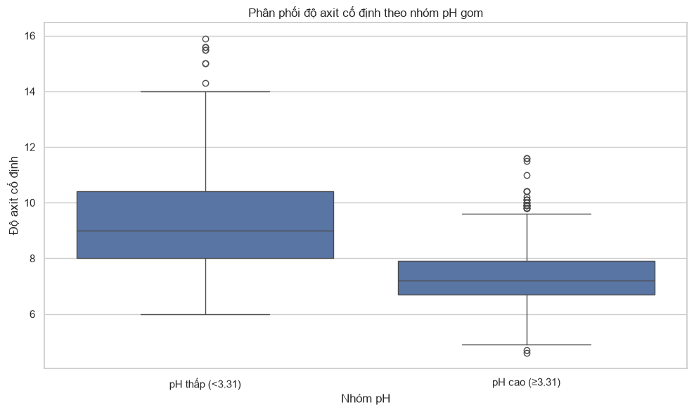

```
=== Thống kê mô tả axit citric theo nhóm gom ===
```

| nhóm pH | Số mẫu | Trung bình | Trung vị | Độ lệch chuẩn | Phương sai |
| --- | --- | --- | --- | --- | --- |
| pH cao (≥3.31) | 816 | 0.181385 | 0.14 | 0.165404 | 0.027358 |
| pH thấp (<3.31) | 783 | 0.364342 | 0.37 | 0.178684 | 0.031928 |

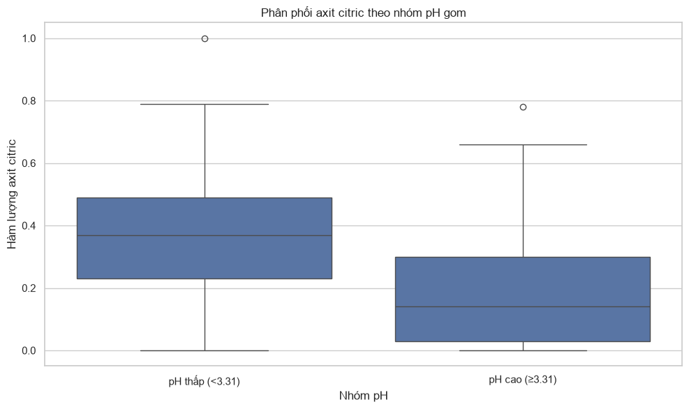

```
=== Kiểm định cho độ axit cố định ===
=== Phương sai hai nhóm (Welch không giả định σ₁ = σ₂) ===
pH cao (≥3.31):  s² = 1.1313,  s = 1.0636
pH thấp (≤3.31): s² = 2.9698,  s = 1.7233

=== Kiểm định Welch t hai mẫu độc lập: H5 / H'5 ===
Thống kê T = -27.8031
Bậc tự do Welch df = 1292.48
Giá trị tới hạn = -1.6460
p-value = 0.000000
Mức ý nghĩa α = 0.05

Bác bỏ H5 ? → True

=== Kiểm định Wilcoxon rank-sum ===
Phương pháp: mẫu lớn (n1=816, n2=783 > 10) → xấp xỉ Z
Thống kê U = 93977.5000
μ_U = 319464.0000,  σ_U = 9229.8646
Z = (U - μ_U) / σ_U = -24.4301
|Z| > Z_α ?  |-24.4301| > -1.6449 → True
p-value = 0.000000
Bác bỏ H5 ? → True

Kết luận: Bác bỏ H5, chấp nhận H'5.
→ Độ axit cố định và hàm lượng axit citric có ảnh hưởng đáng kể với độ pH của rượu vang đỏ.

=== Kiểm định cho axit citric ===
=== Phương sai hai nhóm (Welch không giả định σ₁ = σ₂) ===
pH cao (≥3.31):  s² = 0.0274,  s = 0.1654
pH thấp (≤3.31): s² = 0.0319,  s = 0.1787

=== Kiểm định Welch t hai mẫu độc lập: H5 / H'5 ===
Thống kê T = -21.2248
Bậc tự do Welch df = 1574.98
Giá trị tới hạn = -1.6458
p-value = 0.000000
Mức ý nghĩa α = 0.05

Bác bỏ H5 ? → True

=== Kiểm định Wilcoxon rank-sum ===
Phương pháp: mẫu lớn (n1=816, n2=783 > 10) → xấp xỉ Z
Thống kê U = 145130.5000
μ_U = 319464.0000,  σ_U = 9229.8646
Z = (U - μ_U) / σ_U = -18.8880
|Z| > Z_α ?  |-18.8880| > -1.6449 → True
p-value = 0.000000
Bác bỏ H5 ? → True

Kết luận: Bác bỏ H5, chấp nhận H'5.
→ Độ axit cố định và hàm lượng axit citric có ảnh hưởng đáng kể với độ pH của rượu vang đỏ.
```

```python
# Gom nhóm pH cao / thấp
df_h5 = df.copy()
df_h5["nhóm pH"] = np.where(
    df_h5["pH"] >= 3.31, "pH cao (≥3.31)", "pH thấp (<3.31)"
)

# Ánh xạ từng mức pH → nhóm gom
pH_to_group = (
    df_h5.groupby("pH")
    .size()
    .rename("Số mẫu")
    .to_frame()
    .assign(
        **{
            "Nhóm gom": lambda x: x.index.map(
                lambda q: "pH cao (≥3.31)" if q >= 3.31 else "pH thấp (<3.31)"
            )
        }
    )
)
print("=== Gom nhóm theo pH ===")
display(pH_to_group)

# Thống kê mô tả độ axit cố định theo nhóm gom
fixed_acidity_by_group = (
    df_h5.groupby("nhóm pH")["fixed acidity"]
    .agg(["count", "mean", "median", "std", "var"])
    .rename(
        columns={
            "count": "Số mẫu",
            "mean": "Trung bình",
            "median": "Trung vị",
            "std": "Độ lệch chuẩn",
            "var": "Phương sai",
        }
    )
)
print("\n=== Thống kê mô tả độ axit cố định theo nhóm gom ===")
display(fixed_acidity_by_group)

fig, ax = plt.subplots()
sns.boxplot(data=df_h5, x="nhóm pH", y="fixed acidity", order=["pH thấp (<3.31)", "pH cao (≥3.31)"], ax=ax)
ax.set_xlabel("Nhóm pH")
ax.set_ylabel("Độ axit cố định")
ax.set_title("Phân phối độ axit cố định theo nhóm pH gom")
plt.tight_layout()
plt.show()

# Thống kê mô tả axit citric theo nhóm gom
citric_acid_by_group = (
    df_h5.groupby("nhóm pH")["citric acid"]
    .agg(["count", "mean", "median", "std", "var"])
    .rename(
        columns={
            "count": "Số mẫu",
            "mean": "Trung bình",
            "median": "Trung vị",
            "std": "Độ lệch chuẩn",
            "var": "Phương sai",
        }
    )
)
print("\n=== Thống kê mô tả axit citric theo nhóm gom ===")
display(citric_acid_by_group)

fig, ax = plt.subplots()
sns.boxplot(data=df_h5, x="nhóm pH", y="citric acid", order=["pH thấp (<3.31)", "pH cao (≥3.31)"], ax=ax)
ax.set_xlabel("Nhóm pH")
ax.set_ylabel("Hàm lượng axit citric")
ax.set_title("Phân phối axit citric theo nhóm pH gom")
plt.tight_layout()
plt.show()

# Độ axit cố định - fixed acidity
high_q_fixed = df_h5.loc[df_h5["pH"] >= 3.31, "fixed acidity"]
low_q_fixed = df_h5.loc[df_h5["pH"] < 3.31, "fixed acidity"]

s1_fixed = high_q_fixed.std(ddof=1)
s2_fixed = low_q_fixed.std(ddof=1)
print("\n=== Kiểm định cho độ axit cố định ===")
print("=== Phương sai hai nhóm (Welch không giả định σ₁ = σ₂) ===")
print(f"pH cao (≥3.31):  s² = {s1_fixed**2:.4f},  s = {s1_fixed:.4f}")
print(f"pH thấp (≤3.31): s² = {s2_fixed**2:.4f},  s = {s2_fixed:.4f}")

H5 = "Xác định độ axit cố định và hàm lượng axit citric không có ảnh hưởng tiêu cực với độ pH của rượu vang đỏ."
H5_prime = "Độ axit cố định và hàm lượng axit citric có ảnh hưởng đáng kể với độ pH của rượu vang đỏ."

# Welch t-test hai mẫu độc lập (một phía: μ_cao < μ_thấp (do H'5 kiểm định theo hướng tiêu cực), bác bỏ H5 nếu p < α)
result_h5_fixed_t = hypothesis_test(
    "t_two_means_welch",
    x1=high_q_fixed.mean(),
    x2=low_q_fixed.mean(),
    s1=s1_fixed,
    s2=s2_fixed,
    n1=len(high_q_fixed),
    n2=len(low_q_fixed),
    alpha=ALPHA,
    alternative="less",
)

print("\n=== Kiểm định Welch t hai mẫu độc lập: H5 / H'5 ===")
print(f"Thống kê {result_h5_fixed_t['statistic_name']} = {result_h5_fixed_t['statistic']:.4f}")
print(f"Bậc tự do Welch df = {result_h5_fixed_t['df']:.2f}")
print(f"Giá trị tới hạn = {result_h5_fixed_t['critical_value']:.4f}")
print(f"p-value = {result_h5_fixed_t['p_value']:.6f}")
print(f"Mức ý nghĩa α = {ALPHA}")

reject = result_h5_fixed_t["p_value"] < ALPHA
print(f"\nBác bỏ H5 ? → {reject}")

# Dự phòng phi tham số: Wilcoxon rank-sum
result_h5_fixed_w = hypothesis_test(
    "wilcoxon_rank_sum",
    sample1=high_q_fixed.values,
    sample2=low_q_fixed.values,
    alpha=ALPHA,
    alternative="less",
)

print("\n=== Kiểm định Wilcoxon rank-sum ===")
w = result_h5_fixed_w
if w["use_z_approx"]:
    print(f"Phương pháp: mẫu lớn (n1={w['n1']}, n2={w['n2']} > 10) → xấp xỉ Z")
else:
    print(f"Phương pháp: mẫu nhỏ (n1={w['n1']}, n2={w['n2']} ≤ 10) → tra bảng U / p-value chính xác")
print(f"Thống kê U = {w['statistic']:.4f}")
if w["use_z_approx"]:
    print(f"μ_U = {w['mu_u']:.4f},  σ_U = {w['sigma_u']:.4f}")
    print(f"Z = (U - μ_U) / σ_U = {w['z']:.4f}")
    print(f"|Z| > Z_α ?  |{w['z']:.4f}| > {w['critical_value']:.4f} → {abs(w['z']) > w['critical_value']}")
print(f"p-value = {w['p_value']:.6f}")
print(f"Bác bỏ H5 ? → {w['reject_h0']}")

if reject:
    print("\nKết luận: Bác bỏ H5, chấp nhận H'5.")
    print(f"→ {H5_prime}")
else:
    print("\nKết luận: Không bác bỏ H5.")
    print(f"→ {H5}")

# Hàm lượng axit citric
high_q_citric = df_h5.loc[df_h5["pH"] >= 3.31, "citric acid"]
low_q_citric = df_h5.loc[df_h5["pH"] < 3.31, "citric acid"]

s1_citric = high_q_citric.std(ddof=1)
s2_citric = low_q_citric.std(ddof=1)
print("\n=== Kiểm định cho axit citric ===")
print("=== Phương sai hai nhóm (Welch không giả định σ₁ = σ₂) ===")
print(f"pH cao (≥3.31):  s² = {s1_citric**2:.4f},  s = {s1_citric:.4f}")
print(f"pH thấp (≤3.31): s² = {s2_citric**2:.4f},  s = {s2_citric:.4f}")


# Welch t-test hai mẫu độc lập (một phía: μ_cao < μ_thấp (do H'5 kiểm định theo hướng tiêu cực), bác bỏ H5 nếu p < α)
result_h5_citric_t = hypothesis_test(
    "t_two_means_welch",
    x1=high_q_citric.mean(),
    x2=low_q_citric.mean(),
    s1=s1_citric,
    s2=s2_citric,
    n1=len(high_q_citric),
    n2=len(low_q_citric),
    alpha=ALPHA,
    alternative="less",
)

print("\n=== Kiểm định Welch t hai mẫu độc lập: H5 / H'5 ===")
print(f"Thống kê {result_h5_citric_t['statistic_name']} = {result_h5_citric_t['statistic']:.4f}")
print(f"Bậc tự do Welch df = {result_h5_citric_t['df']:.2f}")
print(f"Giá trị tới hạn = {result_h5_citric_t['critical_value']:.4f}")
print(f"p-value = {result_h5_citric_t['p_value']:.6f}")
print(f"Mức ý nghĩa α = {ALPHA}")

reject = result_h5_citric_t["p_value"] < ALPHA
print(f"\nBác bỏ H5 ? → {reject}")

# Dự phòng phi tham số: Wilcoxon rank-sum
result_h5_citric_w = hypothesis_test(
    "wilcoxon_rank_sum",
    sample1=high_q_citric.values,
    sample2=low_q_citric.values,
    alpha=ALPHA,
    alternative="less",
)

print("\n=== Kiểm định Wilcoxon rank-sum ===")
w = result_h5_citric_w
if w["use_z_approx"]:
    print(f"Phương pháp: mẫu lớn (n1={w['n1']}, n2={w['n2']} > 10) → xấp xỉ Z")
else:
    print(f"Phương pháp: mẫu nhỏ (n1={w['n1']}, n2={w['n2']} ≤ 10) → tra bảng U / p-value chính xác")
print(f"Thống kê U = {w['statistic']:.4f}")
if w["use_z_approx"]:
    print(f"μ_U = {w['mu_u']:.4f},  σ_U = {w['sigma_u']:.4f}")
    print(f"Z = (U - μ_U) / σ_U = {w['z']:.4f}")
    print(f"|Z| > Z_α ?  |{w['z']:.4f}| > {w['critical_value']:.4f} → {abs(w['z']) > w['critical_value']}")
print(f"p-value = {w['p_value']:.6f}")
print(f"Bác bỏ H5 ? → {w['reject_h0']}")

if reject:
    print("\nKết luận: Bác bỏ H5, chấp nhận H'5.")
    print(f"→ {H5_prime}")
else:
    print("\nKết luận: Không bác bỏ H5.")
    print(f"→ {H5}")
```

## 2.7. Kiểm định H6 / H'6 — Welch t-test hai mẫu độc lập (một phía)

**Giả thuyết không (H6):** Hàm lượng cồn cao **không** làm giảm mật độ của rượu vang đỏ.

→ $\mu_{\text{cồn}}(\text{nhóm cao}) - \mu_{\text{còn}}(\text{nhóm thấp}) \geq 0$

**Giả thuyết thay thế (H'6):** Hàm lượng cồn cao có ảnh hưởng tiêu cực đến mật độ của rượu vang đỏ.

→ $\mu_{\text{cồn}}(\text{nhóm cao}) - \mu_{\text{cồn}}(\text{nhóm thấp}) < 0$

**Phương pháp:** Welch t-test hai mẫu độc lập (một phía, **không giả định phương sai bằng nhau**); dự phòng Wilcoxon rank-sum.

**Gom nhóm:**

[output not shown]

**Mức ý nghĩa:** α = 0,05.

```
=== Gom nhóm theo Mật độ ===
```

| density | Số mẫu | Nhóm gom |
| --- | --- | --- |
| 0.99007 | 2 | Mật độ thấp (<0.9968) |
| 0.99020 | 1 | Mật độ thấp (<0.9968) |
| 0.99064 | 2 | Mật độ thấp (<0.9968) |
| 0.99080 | 1 | Mật độ thấp (<0.9968) |
| 0.99084 | 1 | Mật độ thấp (<0.9968) |
| ... | ... | ... |
| 1.00260 | 2 | Mật độ cao (≥0.9968) |
| 1.00289 | 1 | Mật độ cao (≥0.9968) |
| 1.00315 | 3 | Mật độ cao (≥0.9968) |
| 1.00320 | 1 | Mật độ cao (≥0.9968) |
| 1.00369 | 2 | Mật độ cao (≥0.9968) |

436 rows × 2 columns

```
=== Thống kê mô tả nồng độ cồn hơi theo nhóm gom ===
```

| nhóm density | Số mẫu | Trung bình | Trung vị | Độ lệch chuẩn | Phương sai |
| --- | --- | --- | --- | --- | --- |
| Mật độ cao (≥0.9968) | 790 | 10.001160 | 9.8 | 0.816321 | 0.66638 |
| Mật độ thấp (<0.9968) | 809 | 10.834899 | 10.8 | 1.118673 | 1.25143 |

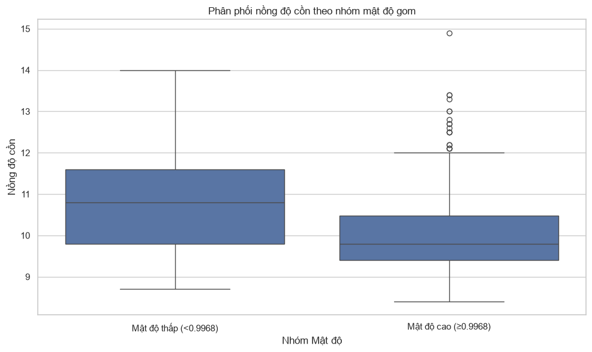

```
=== Phương sai hai nhóm (Welch không giả định σ₁ = σ₂) ===
Mật độ cao (≥0.9968):  s² = 0.6664,  s = 0.8163
Mật độ thấp (<0.9968): s² = 1.2514,  s = 1.1187

=== Kiểm định Welch t hai mẫu độc lập: H6 / H'6 ===
Thống kê T = -17.0527
Bậc tự do Welch df = 1479.07
Giá trị tới hạn = -1.6459
p-value = 0.000000
Mức ý nghĩa α = 0.05

Bác bỏ H6 ? → True

=== Kiểm định Wilcoxon rank-sum ===
Phương pháp: mẫu lớn (n1=790, n2=809 > 10) → xấp xỉ Z
Thống kê U = 175829.5000
μ_U = 319555.0000,  σ_U = 9231.1791
Z = (U - μ_U) / σ_U = -15.5696
|Z| > Z_α ?  |-15.5696| > -1.6449 → True
p-value = 0.000000
Bác bỏ H6 ? → True

Kết luận: Bác bỏ H6, chấp nhận H'6.
→ Hàm lượng cồn cao có ảnh hưởng tiêu cực đến mật độ của rượu vang đỏ.
```

```python
# Gom nhóm density cao / thấp
df_h6 = df.copy()
df_h6["nhóm density"] = np.where(
    df_h6["density"] >= 0.9968, "Mật độ cao (≥0.9968)", "Mật độ thấp (<0.9968)"
)

# Ánh xạ từng mức density → nhóm gom
density_to_group = (
    df_h5.groupby("density")
    .size()
    .rename("Số mẫu")
    .to_frame()
    .assign(
        **{
            "Nhóm gom": lambda x: x.index.map(
                lambda q: "Mật độ cao (≥0.9968)" if q >= 0.9968 else "Mật độ thấp (<0.9968)"
            )
        }
    )
)
print("=== Gom nhóm theo Mật độ ===")
display(density_to_group)

# Thống kê mô tả axit bay hơi theo nhóm gom
alcohol_density_by_group = (
    df_h6.groupby("nhóm density")["alcohol"]
    .agg(["count", "mean", "median", "std", "var"])
    .rename(
        columns={
            "count": "Số mẫu",
            "mean": "Trung bình",
            "median": "Trung vị",
            "std": "Độ lệch chuẩn",
            "var": "Phương sai",
        }
    )
)
print("=== Thống kê mô tả nồng độ cồn hơi theo nhóm gom ===")
display(alcohol_density_by_group)

fig, ax = plt.subplots()
sns.boxplot(
    data=df_h6,
    x="nhóm density",
    y="alcohol",
    order=["Mật độ thấp (<0.9968)", "Mật độ cao (≥0.9968)"],
    ax=ax,
)
ax.set_xlabel("Nhóm Mật độ")
ax.set_ylabel("Nồng độ cồn")
ax.set_title("Phân phối nồng độ cồn theo nhóm mật độ gom")
plt.tight_layout()
plt.show()

high_den = df_h6.loc[df_h6["density"] >= 0.9968, "alcohol"]
low_den = df_h6.loc[df_h6["density"] < 0.9968, "alcohol"]

s1 = high_den.std(ddof=1)
s2 = low_den.std(ddof=1)
print("\n=== Phương sai hai nhóm (Welch không giả định σ₁ = σ₂) ===")
print(f"Mật độ cao (≥0.9968):  s² = {s1**2:.4f},  s = {s1:.4f}")
print(f"Mật độ thấp (<0.9968): s² = {s2**2:.4f},  s = {s2:.4f}")

H6 = "Hàm lượng cồn cao không làm giảm mật độ của rượu vang đỏ."
H6_prime = "Hàm lượng cồn cao có ảnh hưởng tiêu cực đến mật độ của rượu vang đỏ."

# Welch t-test hai mẫu độc lập (một phía: μ_cao < μ_thấp, bác bỏ H2 nếu p < α)
result_h6_t = hypothesis_test(
    "t_two_means_welch",
    x1=high_den.mean(),
    x2=low_den.mean(),
    s1=s1,
    s2=s2,
    n1=len(high_den),
    n2=len(low_den),
    alpha=ALPHA,
    alternative="less",
)

print("\n=== Kiểm định Welch t hai mẫu độc lập: H6 / H'6 ===")
print(f"Thống kê {result_h6_t['statistic_name']} = {result_h6_t['statistic']:.4f}")
print(f"Bậc tự do Welch df = {result_h6_t['df']:.2f}")
print(f"Giá trị tới hạn = {result_h6_t['critical_value']:.4f}")
print(f"p-value = {result_h6_t['p_value']:.6f}")
print(f"Mức ý nghĩa α = {ALPHA}")

reject = result_h6_t["p_value"] < ALPHA
print(f"\nBác bỏ H6 ? → {reject}")

# Dự phòng phi tham số: Wilcoxon rank-sum
result_h6_w = hypothesis_test(
    "wilcoxon_rank_sum",
    sample1=high_den.values,
    sample2=low_den.values,
    alpha=ALPHA,
    alternative="less",
)

print("\n=== Kiểm định Wilcoxon rank-sum ===")
w = result_h6_w
if w["use_z_approx"]:
    print(f"Phương pháp: mẫu lớn (n1={w['n1']}, n2={w['n2']} > 10) → xấp xỉ Z")
else:
    print(f"Phương pháp: mẫu nhỏ (n1={w['n1']}, n2={w['n2']} ≤ 10) → tra bảng U / p-value chính xác")
print(f"Thống kê U = {w['statistic']:.4f}")
if w["use_z_approx"]:
    print(f"μ_U = {w['mu_u']:.4f},  σ_U = {w['sigma_u']:.4f}")
    print(f"Z = (U - μ_U) / σ_U = {w['z']:.4f}")
    print(f"|Z| > Z_α ?  |{w['z']:.4f}| > {w['critical_value']:.4f} → {abs(w['z']) > w['critical_value']}")
print(f"p-value = {w['p_value']:.6f}")
print(f"Bác bỏ H6 ? → {w['reject_h0']}")

if reject:
    print("\nKết luận: Bác bỏ H6, chấp nhận H'6.")
    print(f"→ {H6_prime}")
else:
    print("\nKết luận: Không bác bỏ H6.")
    print(f"→ {H6}")
```

```python
# Xuất toàn bộ notebook ra HTML (folder html/)
from pathlib import Path
import uuid

import nbformat
from nbconvert import HTMLExporter

HTML_DIR = Path("html")
HTML_DIR.mkdir(parents=True, exist_ok=True)

NB_PATH = Path("hypothesis_testing.ipynb")
nb = nbformat.read(NB_PATH, as_version=4)

for cell in nb.cells:
    if "id" not in cell:
        cell["id"] = uuid.uuid4().hex[:8]
    if cell.get("cell_type") != "code":
        continue
    for output in cell.get("outputs", []):
        ot = output.get("output_type")
        if ot == "stream" and "name" not in output:
            output["name"] = "stdout"
        if ot in ("display_data", "execute_result") and "metadata" not in output:
            output["metadata"] = {}
        if ot == "execute_result" and "execution_count" not in output:
            output["execution_count"] = cell.get("execution_count")

body, _ = HTMLExporter().from_notebook_node(nb)
out_path = HTML_DIR / NB_PATH.with_suffix(".html").name
out_path.write_text(body, encoding="utf-8")
print(f"Đã xuất: {out_path}")
```